# DEFENSIVE TRAITS M.polymorpha SIBECOL 2025

Andrés Delgado Galán

2025-05-18

### M.polymorpha - PRODUCCIÓN DE FLORES

**flor ~ trat + clip + trat:clip**  
n = **51**

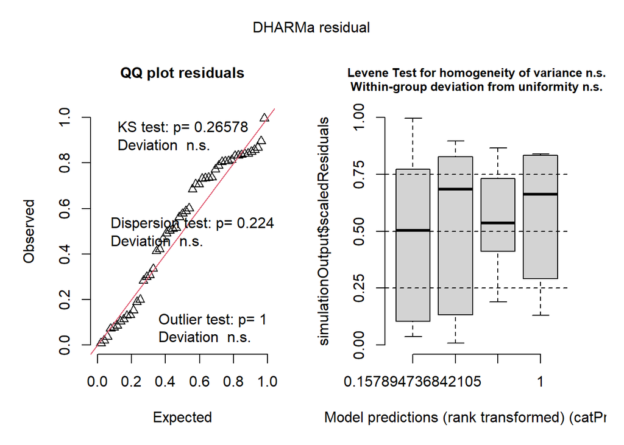

R² = ****

##### MEflor Post-hoc Comparisons with Tukeys HSD

| contrast | trat | estimate | SE | df | z.ratio | p.value |
| --- | --- | --- | --- | --- | --- | --- |
| no - yes | ex | 0.2177345 | 0.3442803 | Inf | 0.6324338 | 0.5271034 |
| no - yes | gra | 0.5761459 | 0.4047410 | Inf | 1.4234929 | 0.1545933 |

| contrast | clip | estimate | SE | df | z.ratio | p.value |
| --- | --- | --- | --- | --- | --- | --- |
| ex - gra | no | -0.8303207 | 0.4005532 | Inf | -2.072935 | 0.0381783 |
| ex - gra | yes | -0.4719093 | 0.3491437 | Inf | -1.351619 | 0.1764971 |

ANOVA Results for MEflor Model

| Response | Predictor | Chisq | Df | Pr(>Chisq) |
| --- | --- | --- | --- | --- |
| ME flor | trat * | 5.669 | 1 | 0.017 |
| ME flor | clip | 1.971 | 1 | 0.160 |
| ME flor | trat:clip | 0.455 | 1 | 0.500 |

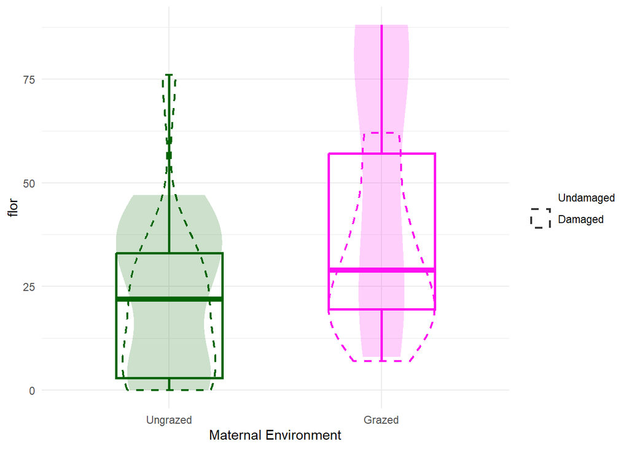

### M.polymorpha - PRODUCCIÓN DE FRUTOS

**fruto ~ trat + clip + trat:clip**  
n = **51**

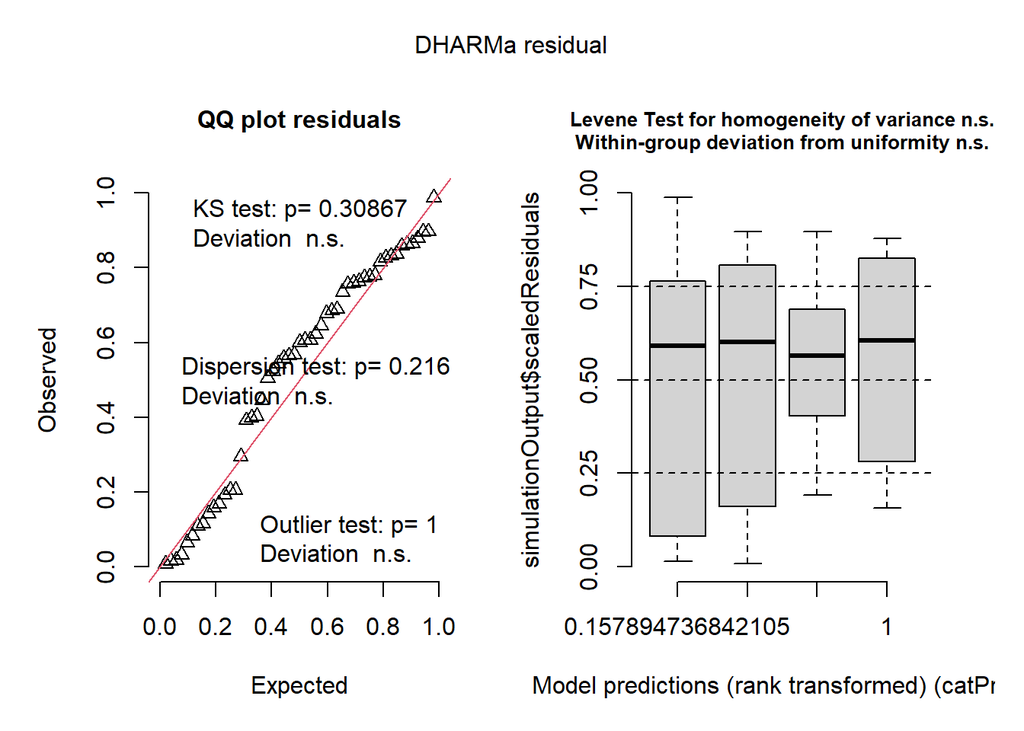

R² = ****

##### MEfruto Post-hoc Comparisons with Tukeys HSD

| contrast | trat | estimate | SE | df | z.ratio | p.value |
| --- | --- | --- | --- | --- | --- | --- |
| no - yes | ex | 0.2249194 | 0.3695780 | Inf | 0.6085844 | 0.5427999 |
| no - yes | gra | 0.4165152 | 0.4348201 | Inf | 0.9579024 | 0.3381120 |

| contrast | clip | estimate | SE | df | z.ratio | p.value |
| --- | --- | --- | --- | --- | --- | --- |
| ex - gra | no | -0.7512112 | 0.4305044 | Inf | -1.744956 | 0.0809925 |
| ex - gra | yes | -0.5596153 | 0.3745963 | Inf | -1.493916 | 0.1351976 |

ANOVA Results for MEfruto Model

| Response | Predictor | Chisq | Df | Pr(>Chisq) |
| --- | --- | --- | --- | --- |
| ME fruto | trat * | 5.164 | 1 | 0.023 |
| ME fruto | clip | 1.175 | 1 | 0.278 |
| ME fruto | trat:clip | 0.113 | 1 | 0.737 |

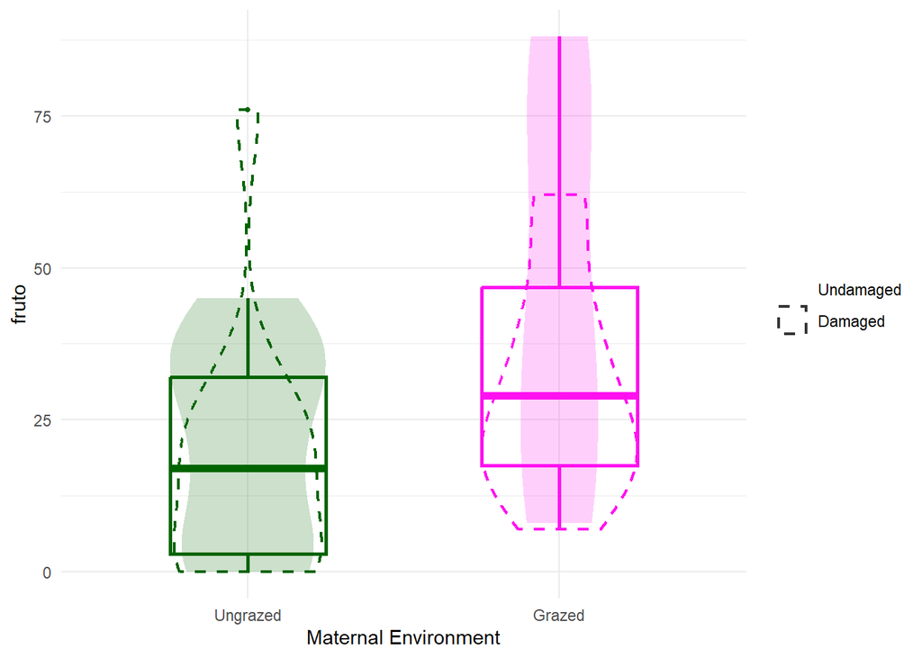

**hojas ~ trat + clip + trat:clip**  
n = **52**

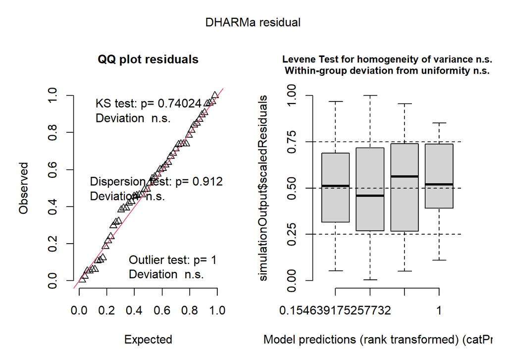

R² = ****

##### MEhojas Post-hoc Comparisons with Tukeys HSD

| contrast | trat | estimate | SE | df | z.ratio | p.value |
| --- | --- | --- | --- | --- | --- | --- |
| no - yes | ex | 0.1588892 | 0.1375589 | Inf | 1.155063 | 0.2480646 |
| no - yes | gra | 0.3108137 | 0.1668857 | Inf | 1.862434 | 0.0625419 |

| contrast | clip | estimate | SE | df | z.ratio | p.value |
| --- | --- | --- | --- | --- | --- | --- |
| ex - gra | no | -0.1154943 | 0.1647705 | Inf | -0.7009404 | 0.4833402 |
| ex - gra | yes | 0.0364302 | 0.1400856 | Inf | 0.2600567 | 0.7948200 |

ANOVA Results for MEhojas Model

| Response | Predictor | Chisq | Df | Pr(>Chisq) |
| --- | --- | --- | --- | --- |
| ME hojas | trat | 0.065 | 1 | 0.798 |
| ME hojas | clip * | 4.309 | 1 | 0.038 |
| ME hojas | trat:clip | 0.493 | 1 | 0.482 |

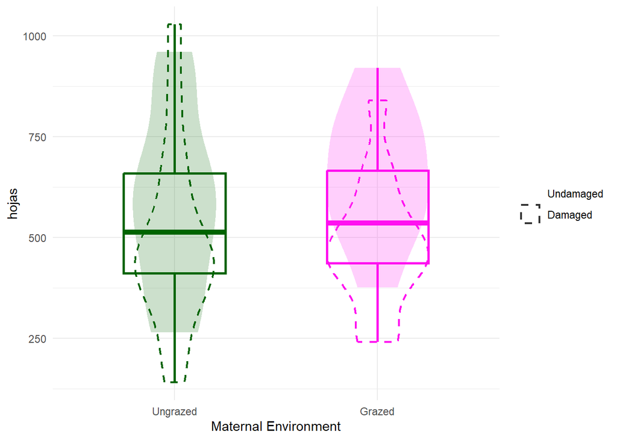

### M.polymorpha - ALTURA MÁXIMA

**altura ~ trat + clip + trat:clip**  
n = **55**

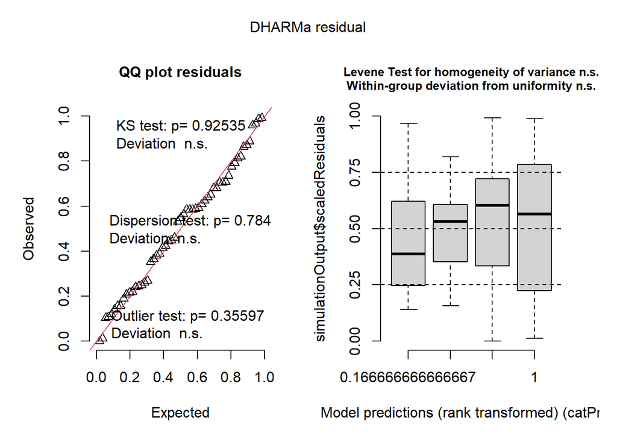

R² = **0.5910142**

##### MEaltura Post-hoc Comparisons with Tukeys HSD

| contrast | trat | estimate | SE | df | t.ratio | p.value |
| --- | --- | --- | --- | --- | --- | --- |
| no - yes | ex | 42.360 | 6.303796 | 51 | 6.719761 | 0e+00 |
| no - yes | gra | 41.375 | 6.910994 | 51 | 5.986838 | 2e-07 |

| contrast | clip | estimate | SE | df | t.ratio | p.value |
| --- | --- | --- | --- | --- | --- | --- |
| ex - gra | no | 0.5583333 | 6.686185 | 51 | 0.0835055 | 0.9337765 |
| ex - gra | yes | -0.4266667 | 6.541758 | 51 | -0.0652220 | 0.9482522 |

ANOVA Results for MEaltura Model

| Response | Predictor | Sum Sq | Df | F value | Pr(>F) |
| --- | --- | --- | --- | --- | --- |
| ME altura | trat | 0.041 | 1 | 0.000 | 0.991 |
| ME altura | clip *** | 24136.665 | 1 | 80.986 | 0.000 |
| ME altura | trat:clip | 3.305 | 1 | 0.011 | 0.917 |
| ME altura | Residuals | 15199.725 | 51 | NA | NA |

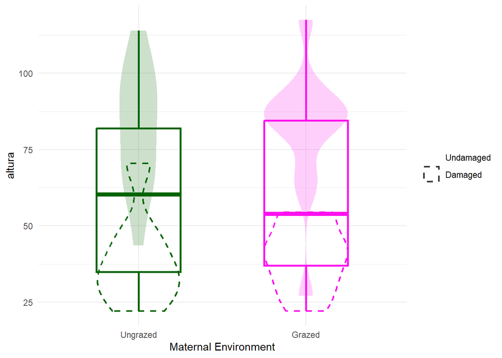

### M.polymorpha - SEMILLAS/FRUTO

**seedfruto ~ trat + clip + trat:clip**  
n = **46**

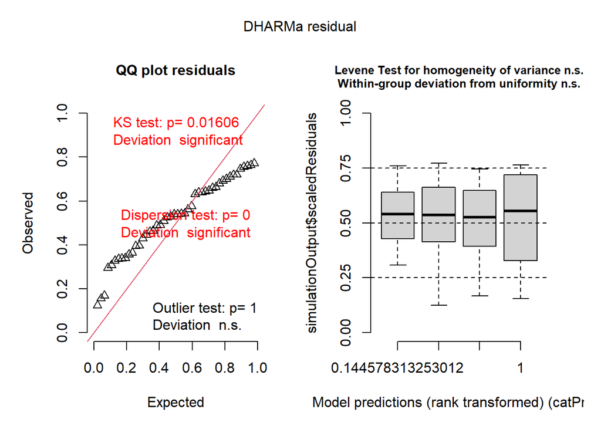

R² = ****

##### MEseedfruto Post-hoc Comparisons with Tukeys HSD

| contrast | trat | estimate | SE | df | z.ratio | p.value |
| --- | --- | --- | --- | --- | --- | --- |
| no - yes | ex | 0.1646885 | 0.1612616 | Inf | 1.0212508 | 0.3071356 |
| no - yes | gra | -0.0212556 | 0.1444212 | Inf | -0.1471781 | 0.8829914 |

| contrast | clip | estimate | SE | df | z.ratio | p.value |
| --- | --- | --- | --- | --- | --- | --- |
| ex - gra | no | 0.0463926 | 0.1533241 | Inf | 0.3025786 | 0.7622110 |
| ex - gra | yes | -0.1395516 | 0.1528218 | Inf | -0.9131652 | 0.3611557 |

ANOVA Results for MEseedfruto Model

| Response | Predictor | Chisq | Df | Pr(>Chisq) |
| --- | --- | --- | --- | --- |
| ME seedfruto | trat | 0.188 | 1 | 0.665 |
| ME seedfruto | clip | 0.327 | 1 | 0.568 |
| ME seedfruto | trat:clip | 0.738 | 1 | 0.390 |

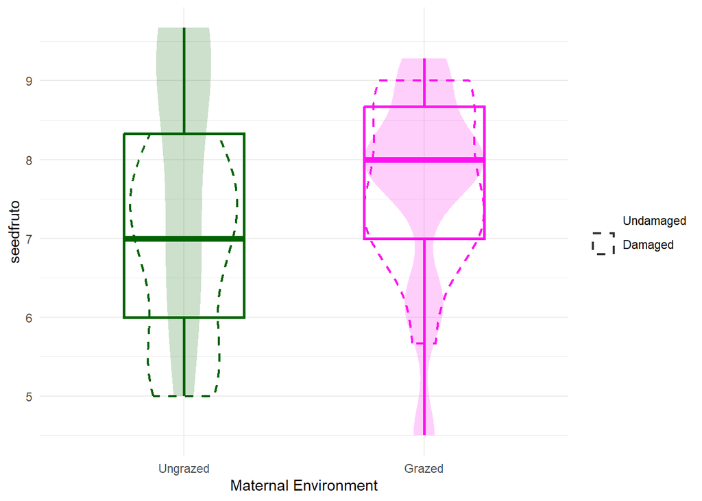

### M.polymorpha - PRODUCCIÓN DE SEMILLAS

**seedtotal ~ trat + clip + trat:clip**  
n = **51**

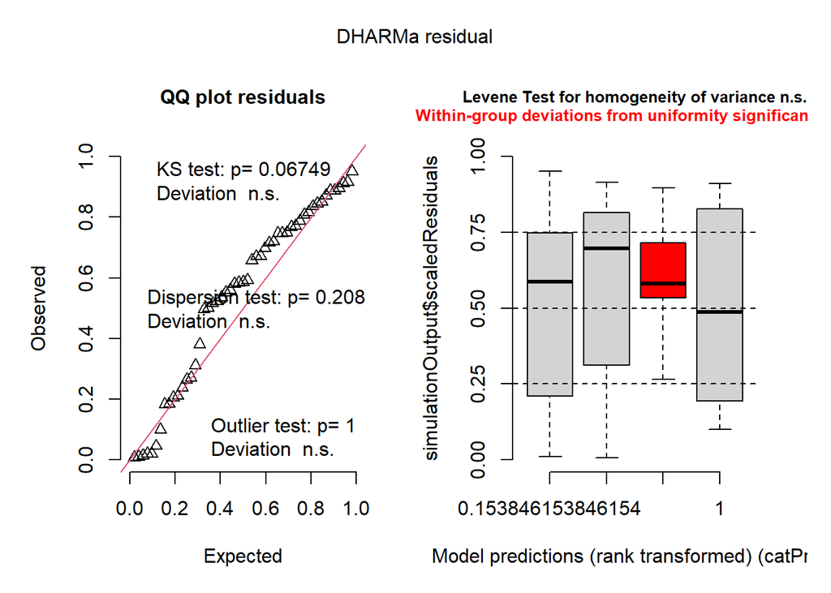

R² = ****

##### MEseedtotal Post-hoc Comparisons with Tukeys HSD

| contrast | trat | estimate | SE | df | z.ratio | p.value |
| --- | --- | --- | --- | --- | --- | --- |
| no - yes | ex | 0.2091987 | 0.4979387 | Inf | 0.4201294 | 0.6743909 |
| no - yes | gra | 0.0249133 | 0.5078313 | Inf | 0.0490582 | 0.9608729 |

| contrast | clip | estimate | SE | df | z.ratio | p.value |
| --- | --- | --- | --- | --- | --- | --- |
| ex - gra | no | -0.3421946 | 0.5079545 | Inf | -0.6736716 | 0.5005201 |
| ex - gra | yes | -0.5264800 | 0.4978130 | Inf | -1.0575857 | 0.2902444 |

ANOVA Results for MEseedtotal Model

| Response | Predictor | Chisq | Df | Pr(>Chisq) |
| --- | --- | --- | --- | --- |
| ME seedtotal | trat | 1.505 | 1 | 0.220 |
| ME seedtotal | clip | 0.112 | 1 | 0.738 |
| ME seedtotal | trat:clip | 0.067 | 1 | 0.796 |

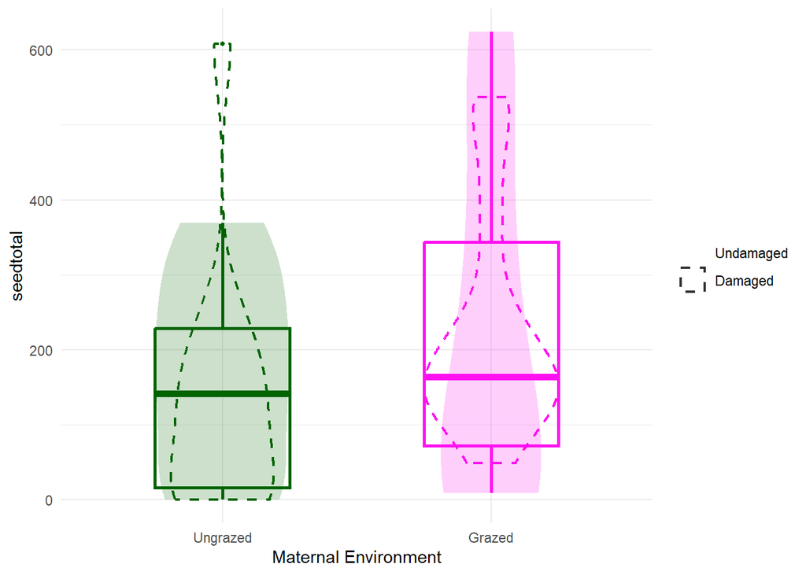

### M.polymorpha - PESO MEDIO DE LAS SEMILLAS

**massseed ~ trat + clip + trat:clip**  
n = **47**

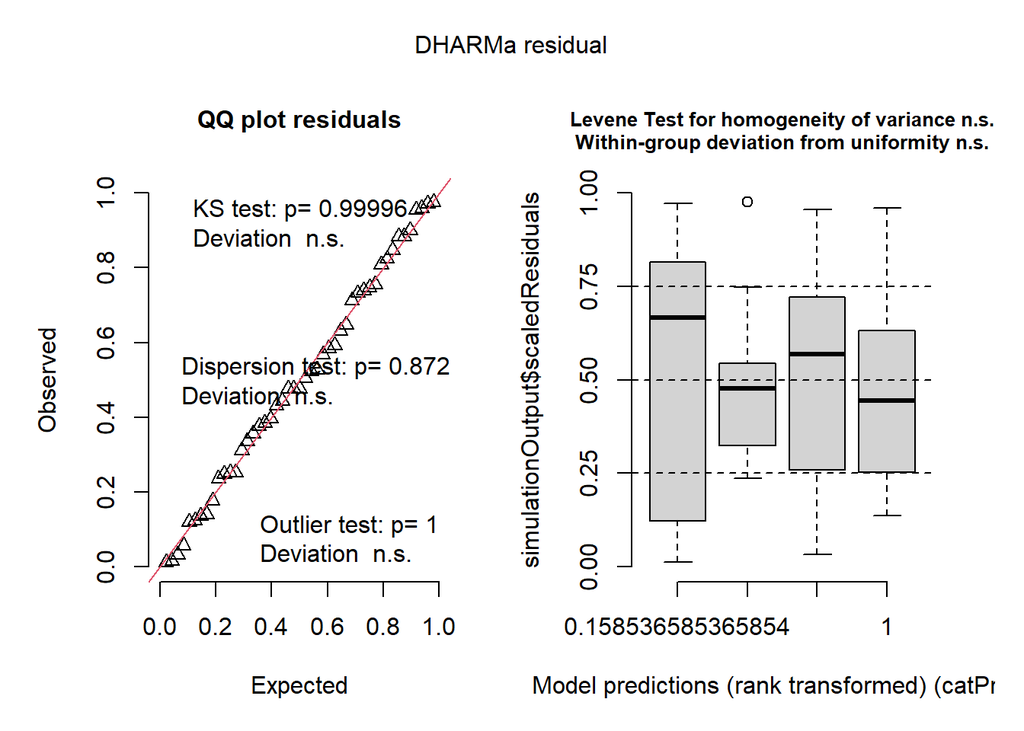

R² = **-0.0479408**

##### MEmassseed Post-hoc Comparisons with Tukeys HSD

| contrast | trat | estimate | SE | df | t.ratio | p.value |
| --- | --- | --- | --- | --- | --- | --- |
| no - yes | ex | 0.0000273 | 0.0003146 | 43 | 0.0866990 | 0.9313132 |
| no - yes | gra | -0.0002365 | 0.0002953 | 43 | -0.8009372 | 0.4275715 |

| contrast | clip | estimate | SE | df | t.ratio | p.value |
| --- | --- | --- | --- | --- | --- | --- |
| ex - gra | no | 0.0000295 | 0.0003079 | 43 | 0.0959441 | 0.9240108 |
| ex - gra | yes | -0.0002343 | 0.0003022 | 43 | -0.7751318 | 0.4425037 |

ANOVA Results for MEmassseed Model

| Response | Predictor | Sum Sq | Df | F value | Pr(>F) |
| --- | --- | --- | --- | --- | --- |
| ME massseed | trat | 0 | 1 | 0.236 | 0.629 |
| ME massseed | clip | 0 | 1 | 0.275 | 0.603 |
| ME massseed | trat:clip | 0 | 1 | 0.374 | 0.544 |
| ME massseed | Residuals | 0 | 43 | NA | NA |

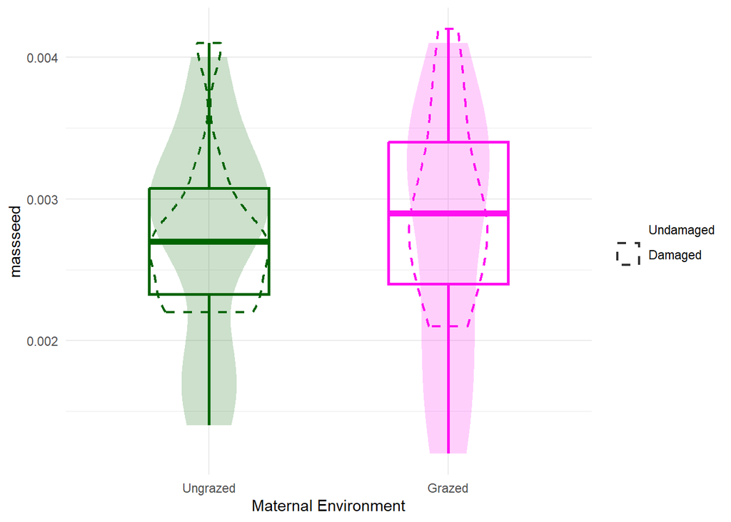

### M.polymorpha - SLA

**SLA ~ trat + clip + trat:clip**  
n = **44**

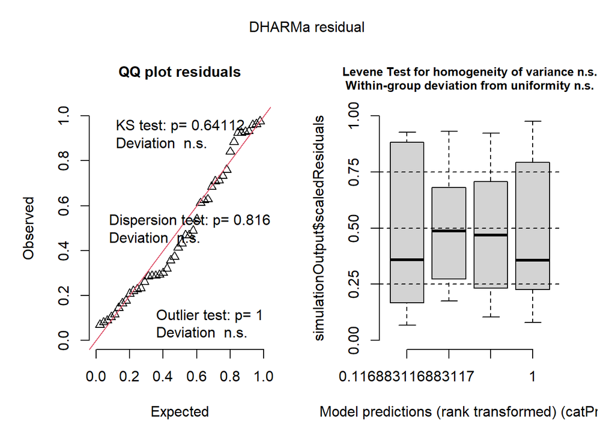

R² = **-0.0268505**

##### MESLA Post-hoc Comparisons with Tukeys HSD

| contrast | trat | estimate | SE | df | t.ratio | p.value |
| --- | --- | --- | --- | --- | --- | --- |
| no - yes | ex | -27.697551 | 32.33053 | 40 | -0.8566996 | 0.3967144 |
| no - yes | gra | -4.613703 | 37.52672 | 40 | -0.1229445 | 0.9027667 |

| contrast | clip | estimate | SE | df | t.ratio | p.value |
| --- | --- | --- | --- | --- | --- | --- |
| ex - gra | no | 15.46561 | 36.29093 | 40 | 0.4261565 | 0.6722784 |
| ex - gra | yes | 38.54946 | 33.71181 | 40 | 1.1435002 | 0.2596286 |

ANOVA Results for MESLA Model

| Response | Predictor | Sum Sq | Df | F value | Pr(>F) |
| --- | --- | --- | --- | --- | --- |
| ME SLA | trat | 8296.666 | 1 | 1.272 | 0.266 |
| ME SLA | clip | 3469.064 | 1 | 0.532 | 0.470 |
| ME SLA | trat:clip | 1416.568 | 1 | 0.217 | 0.644 |
| ME SLA | Residuals | 260897.667 | 40 | NA | NA |

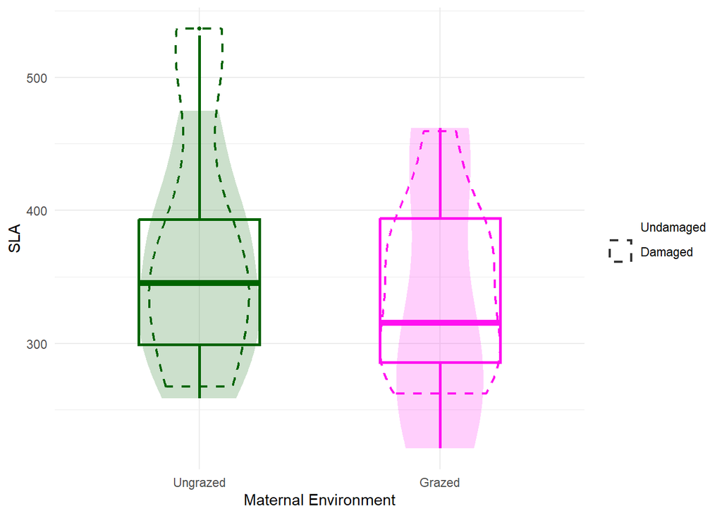

### M.polymorpha - LDMC

**LDMC ~ trat + clip + trat:clip**  
n = **47**

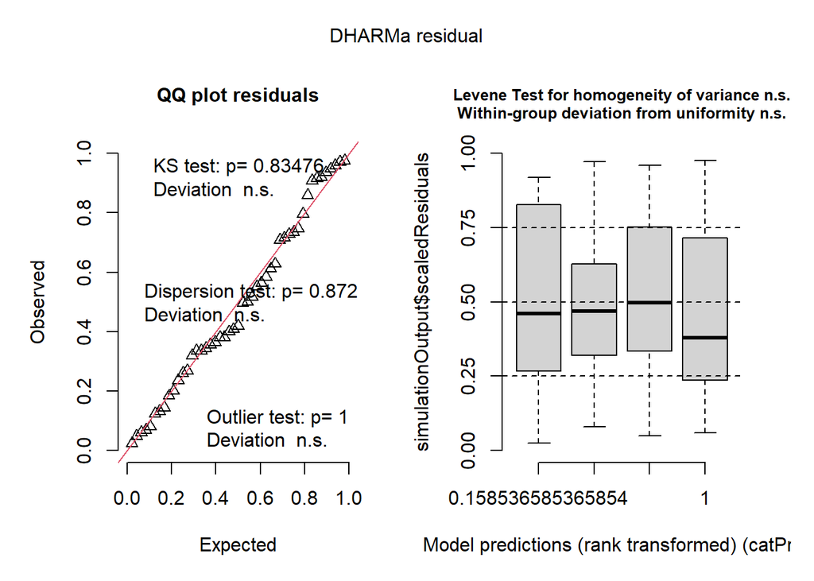

R² = **0.1113507**

##### MELDMC Post-hoc Comparisons with Tukeys HSD

| contrast | trat | estimate | SE | df | t.ratio | p.value |
| --- | --- | --- | --- | --- | --- | --- |
| no - yes | ex | 0.0268666 | 0.0097937 | 43 | 2.7432508 | 0.0088353 |
| no - yes | gra | -0.0060473 | 0.0104752 | 43 | -0.5773021 | 0.5667460 |

| contrast | clip | estimate | SE | df | t.ratio | p.value |
| --- | --- | --- | --- | --- | --- | --- |
| ex - gra | no | 0.022999 | 0.0102904 | 43 | 2.2349917 | 0.0306653 |
| ex - gra | yes | -0.009915 | 0.0099877 | 43 | -0.9927243 | 0.3263980 |

ANOVA Results for MELDMC Model

| Response | Predictor | Sum Sq | Df | F value | Pr(>F) |
| --- | --- | --- | --- | --- | --- |
| ME LDMC | trat | 0.000 | 1 | 0.713 | 0.403 |
| ME LDMC | clip | 0.002 | 1 | 2.591 | 0.115 |
| ME LDMC | trat:clip * | 0.003 | 1 | 5.268 | 0.027 |
| ME LDMC | Residuals | 0.026 | 43 | NA | NA |

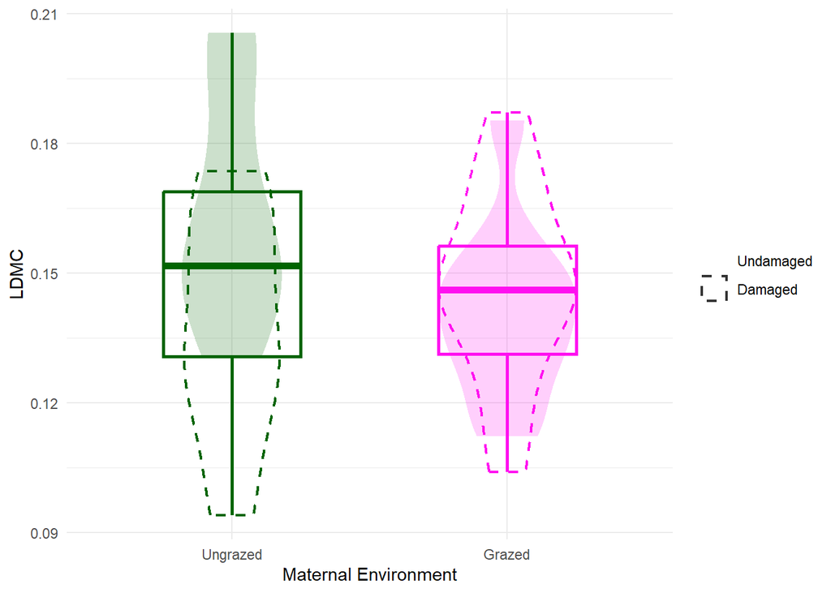

### M.polymorpha - ÁREA FOLIAR

**area.m ~ trat + clip + trat:clip**  
n = **49**

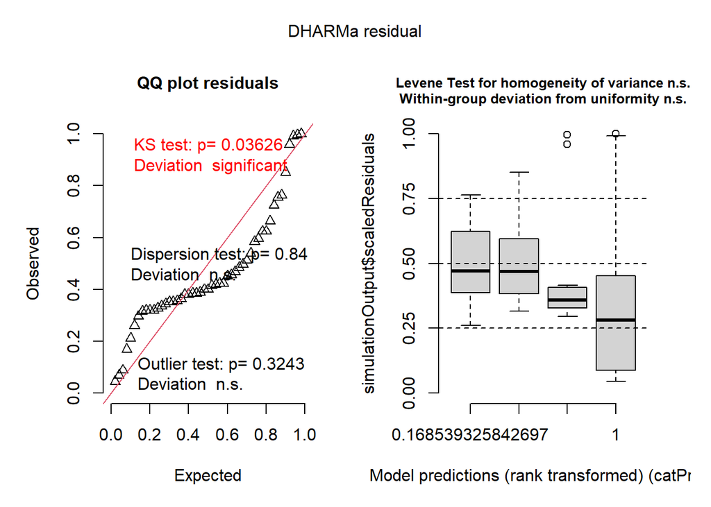

R² = **0.0505469**

##### MEarea.m Post-hoc Comparisons with Tukeys HSD

| contrast | trat | estimate | SE | df | t.ratio | p.value |
| --- | --- | --- | --- | --- | --- | --- |
| no - yes | ex | 0.1790092 | 0.8515276 | 45 | 0.2102212 | 0.8344440 |
| no - yes | gra | 1.5564611 | 0.9466147 | 45 | 1.6442393 | 0.1070961 |

| contrast | clip | estimate | SE | df | t.ratio | p.value |
| --- | --- | --- | --- | --- | --- | --- |
| ex - gra | no | -1.8201385 | 0.9299183 | 45 | -1.9573101 | 0.056531 |
| ex - gra | yes | -0.4426865 | 0.8697302 | 45 | -0.5089929 | 0.613244 |

ANOVA Results for MEarea.m Model

| Response | Predictor | Sum Sq | Df | F value | Pr(>F) |
| --- | --- | --- | --- | --- | --- |
| ME area.m | trat · | 14.271 | 1 | 2.920 | 0.094 |
| ME area.m | clip | 7.710 | 1 | 1.577 | 0.216 |
| ME area.m | trat:clip | 5.720 | 1 | 1.170 | 0.285 |
| ME area.m | Residuals | 219.947 | 45 | NA | NA |

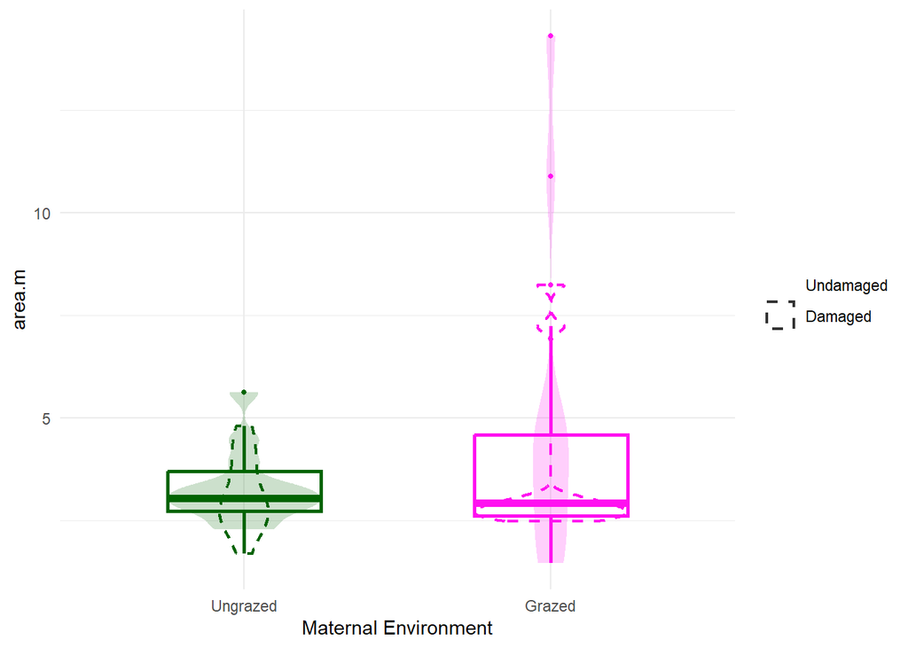

Quité los valores extremos con el SLA y tampoco salía bien. Habría que mirar estos valores de area foliar tan altos pero aún así no parece haber ningún patrón.

### M.polymorpha - FENOLOGÍA DE FLORACIÓN

**dias_flor ~ trat + clip + trat:clip**  
n = **52**

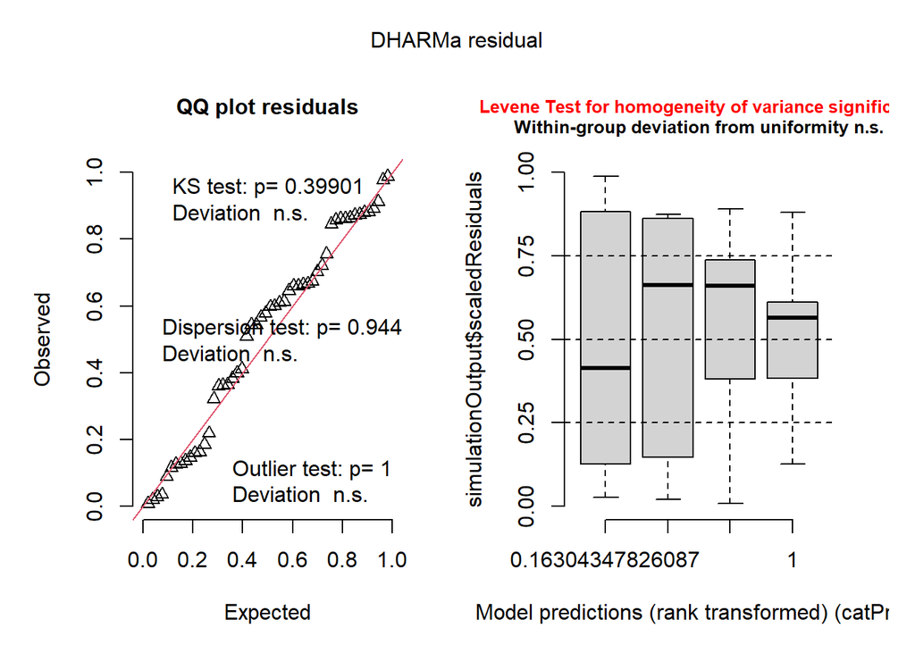

R² = ****

##### MEdias_flor Post-hoc Comparisons with Tukeys HSD

| contrast | trat | estimate | SE | df | z.ratio | p.value |
| --- | --- | --- | --- | --- | --- | --- |
| no - yes | ex | 0.0135668 | 0.0614648 | Inf | 0.2207241 | 0.8253073 |
| no - yes | gra | 0.1243553 | 0.0698828 | Inf | 1.7794825 | 0.0751607 |

| contrast | clip | estimate | SE | df | z.ratio | p.value |
| --- | --- | --- | --- | --- | --- | --- |
| ex - gra | no | 0.1246550 | 0.0692460 | Inf | 1.800177 | 0.0718328 |
| ex - gra | yes | 0.2354435 | 0.0621814 | Inf | 3.786400 | 0.0001528 |

ANOVA Results for MEdias_flor Model

| Response | Predictor | Chisq | Df | Pr(>Chisq) |
| --- | --- | --- | --- | --- |
| ME dias_flor | trat *** | 16.160 | 1 | 0.000 |
| ME dias_flor | clip | 1.798 | 1 | 0.180 |
| ME dias_flor | trat:clip | 1.417 | 1 | 0.234 |

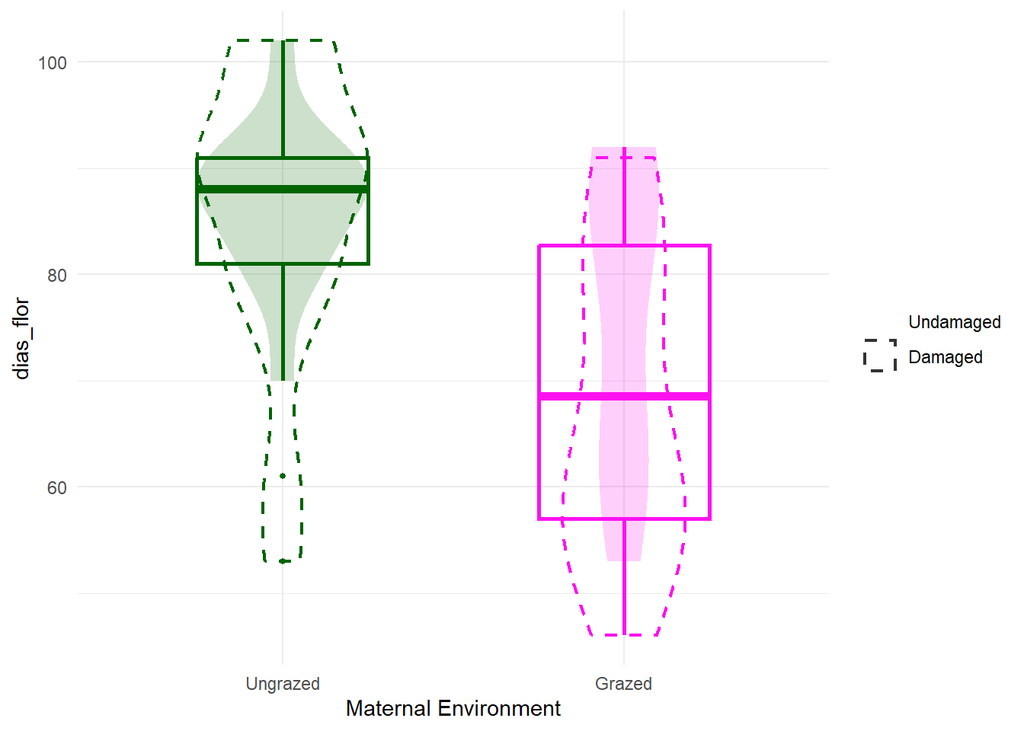

### M.polymorpha - FENOLOGÍA DE FRUCTIFICACÓN

**dias_fruto ~ trat + clip + trat:clip**  
n = **48**

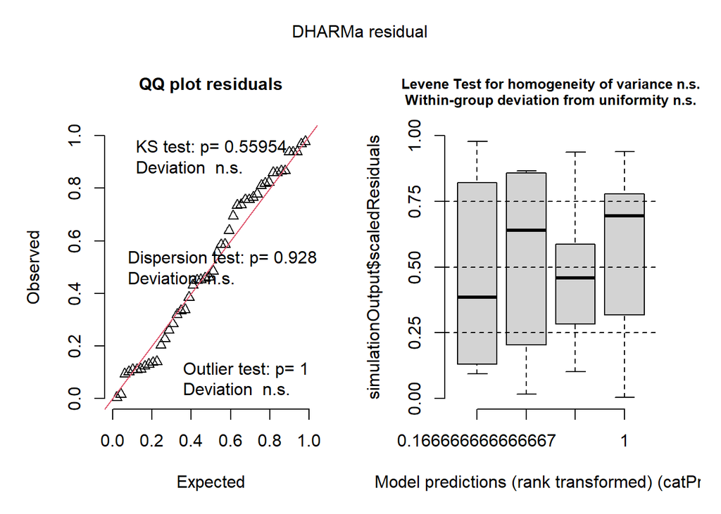

R² = ****

##### MEdias_fruto Post-hoc Comparisons with Tukeys HSD

| contrast | trat | estimate | SE | df | z.ratio | p.value |
| --- | --- | --- | --- | --- | --- | --- |
| no - yes | ex | -0.0447143 | 0.0526944 | Inf | -0.8485586 | 0.3961269 |
| no - yes | gra | 0.1403795 | 0.0607846 | Inf | 2.3094569 | 0.0209182 |

| contrast | clip | estimate | SE | df | z.ratio | p.value |
| --- | --- | --- | --- | --- | --- | --- |
| ex - gra | no | 0.0542696 | 0.0592399 | Inf | 0.9160993 | 0.3596148 |
| ex - gra | yes | 0.2393635 | 0.0544253 | Inf | 4.3980219 | 0.0000109 |

ANOVA Results for MEdias_fruto Model

| Response | Predictor | Chisq | Df | Pr(>Chisq) |
| --- | --- | --- | --- | --- |
| ME dias_fruto | trat *** | 14.888 | 1 | 0.000 |
| ME dias_fruto | clip | 0.760 | 1 | 0.383 |
| ME dias_fruto | trat:clip * | 5.294 | 1 | 0.021 |

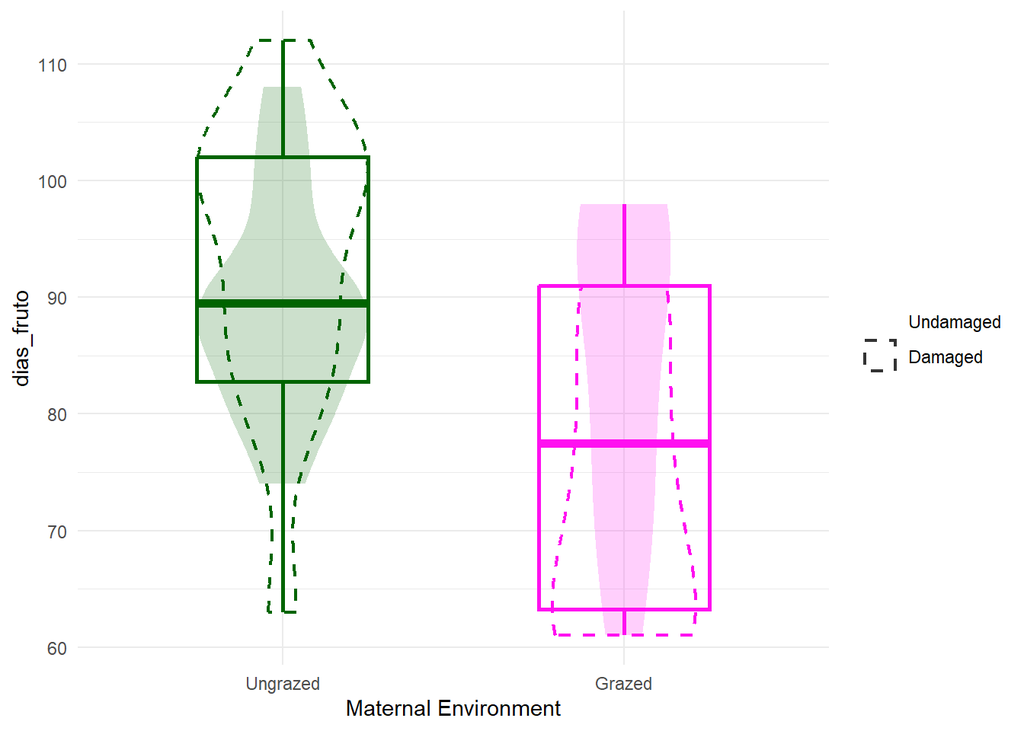

### M.polymorpha - PERIODO DE FLORACIÓN

**periodo_flor ~ trat + clip + trat:clip**  
n = **47**

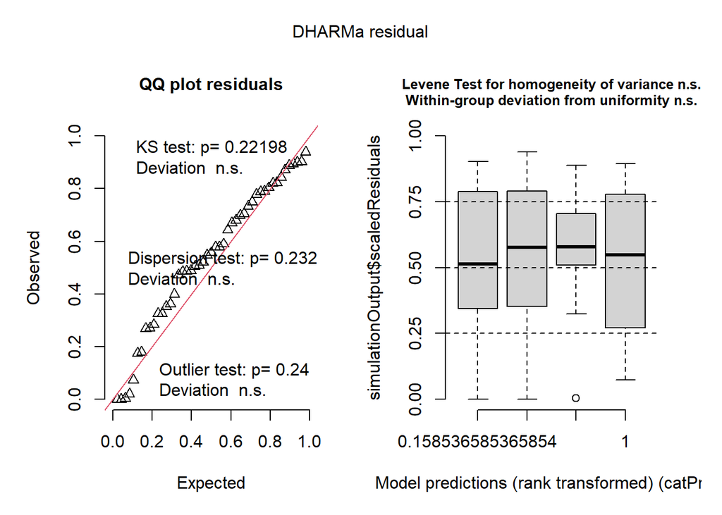

R² = ****

##### MEperiodo_flor Post-hoc Comparisons with Tukeys HSD

| contrast | trat | estimate | SE | df | z.ratio | p.value |
| --- | --- | --- | --- | --- | --- | --- |
| no - yes | ex | -0.2404278 | 0.2040245 | Inf | -1.1784260 | 0.2386268 |
| no - yes | gra | -0.1404997 | 0.2122293 | Inf | -0.6620185 | 0.5079594 |

| contrast | clip | estimate | SE | df | z.ratio | p.value |
| --- | --- | --- | --- | --- | --- | --- |
| ex - gra | no | -0.601681 | 0.2211128 | Inf | -2.721150 | 0.0065055 |
| ex - gra | yes | -0.501753 | 0.1943616 | Inf | -2.581544 | 0.0098360 |

ANOVA Results for MEperiodo_flor Model

| Response | Predictor | Chisq | Df | Pr(>Chisq) |
| --- | --- | --- | --- | --- |
| ME periodo_flor | trat *** | 13.954 | 1 | 0.000 |
| ME periodo_flor | clip | 1.712 | 1 | 0.191 |
| ME periodo_flor | trat:clip | 0.115 | 1 | 0.734 |

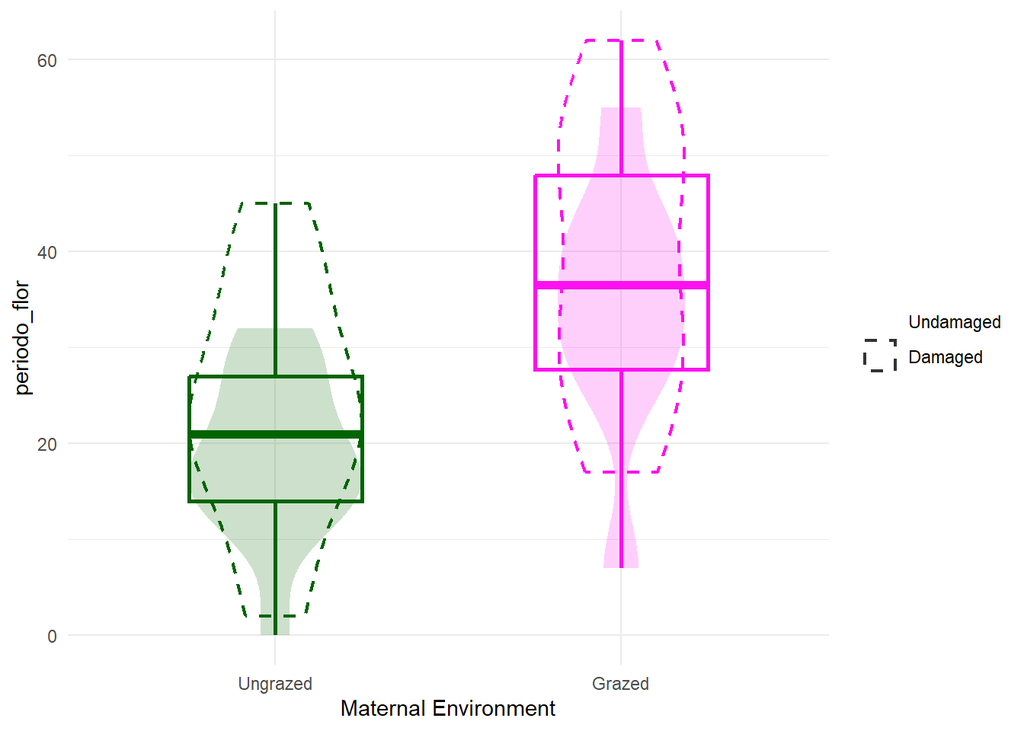

### M.polymorpha - PERIODO DE FRUCTIFICACIÓN

**periodo_fruto ~ trat + clip + trat:clip**

n = **44**

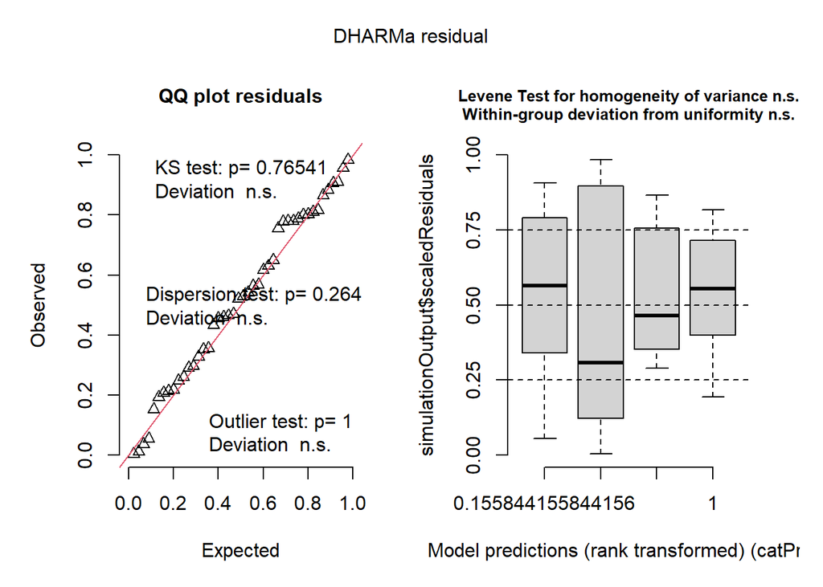

##### MEperiodo_fruto Post-hoc Comparisons with Tukeys HSD

| contrast | trat | estimate | SE | df | z.ratio | p.value |
| --- | --- | --- | --- | --- | --- | --- |
| no - yes | ex | -0.2116255 | 0.2153129 | Inf | -0.9828745 | 0.3256692 |
| no - yes | gra | -0.2322759 | 0.2191986 | Inf | -1.0596592 | 0.2892996 |

| contrast | clip | estimate | SE | df | z.ratio | p.value |
| --- | --- | --- | --- | --- | --- | --- |
| ex - gra | no | -0.5656819 | 0.2287294 | Inf | -2.473149 | 0.0133928 |
| ex - gra | yes | -0.5863322 | 0.2051598 | Inf | -2.857930 | 0.0042641 |

ANOVA Results for MEperiodo_fruto Model

| Response | Predictor | Chisq | Df | Pr(>Chisq) |
| --- | --- | --- | --- | --- |
| ME periodo_fruto | trat *** | 14.280 | 1 | 0.000 |
| ME periodo_fruto | clip | 2.084 | 1 | 0.149 |
| ME periodo_fruto | trat:clip | 0.005 | 1 | 0.946 |

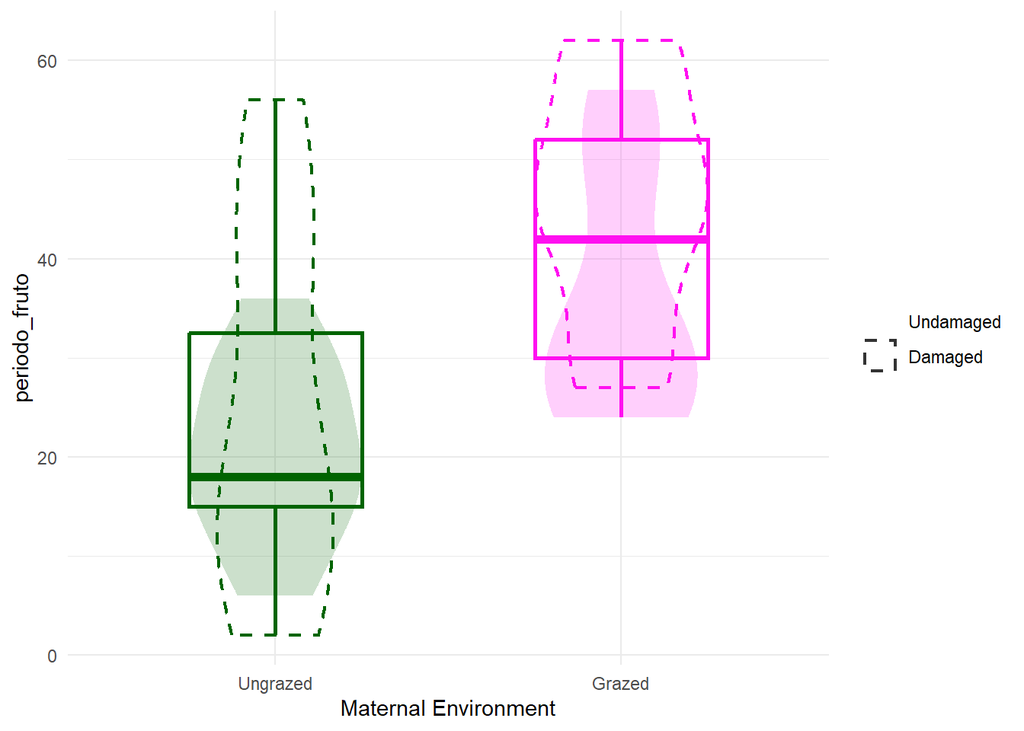

### M.polymorpha - dias_fin DE FLORACIÓN

**dias_fin_flor ~ trat + clip + trat:clip**  
n = **50**

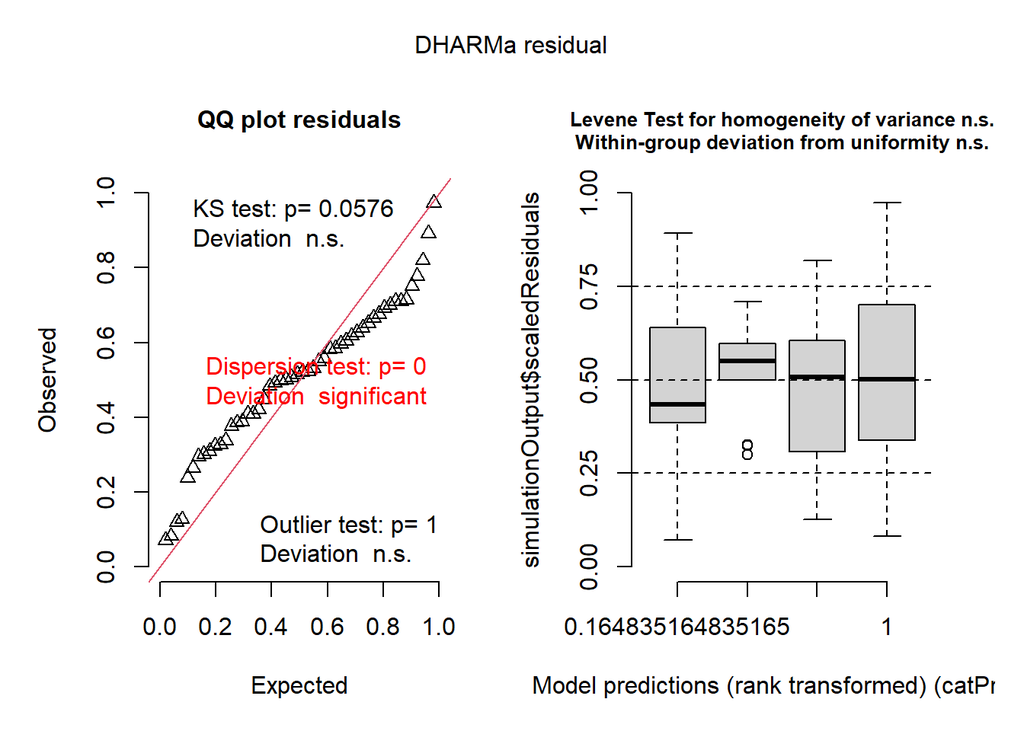

##### MEdias_fin_flor Post-hoc Comparisons with Tukeys HSD

| contrast | trat | estimate | SE | df | z.ratio | p.value |
| --- | --- | --- | --- | --- | --- | --- |
| no - yes | ex | -0.0399940 | 0.0373186 | Inf | -1.071690 | 0.2838593 |
| no - yes | gra | 0.0433253 | 0.0400722 | Inf | 1.081183 | 0.2796159 |

| contrast | clip | estimate | SE | df | z.ratio | p.value |
| --- | --- | --- | --- | --- | --- | --- |
| ex - gra | no | -0.0733548 | 0.0396854 | Inf | -1.8484066 | 0.0645435 |
| ex - gra | yes | 0.0099645 | 0.0377296 | Inf | 0.2641024 | 0.7917010 |

ANOVA Results for MEdias_fin_flor Model

| Response | Predictor | Chisq | Df | Pr(>Chisq) |
| --- | --- | --- | --- | --- |
| ME dias_fin_flor | trat | 1.171 | 1 | 0.279 |
| ME dias_fin_flor | clip | 0.002 | 1 | 0.962 |
| ME dias_fin_flor | trat:clip | 2.315 | 1 | 0.128 |

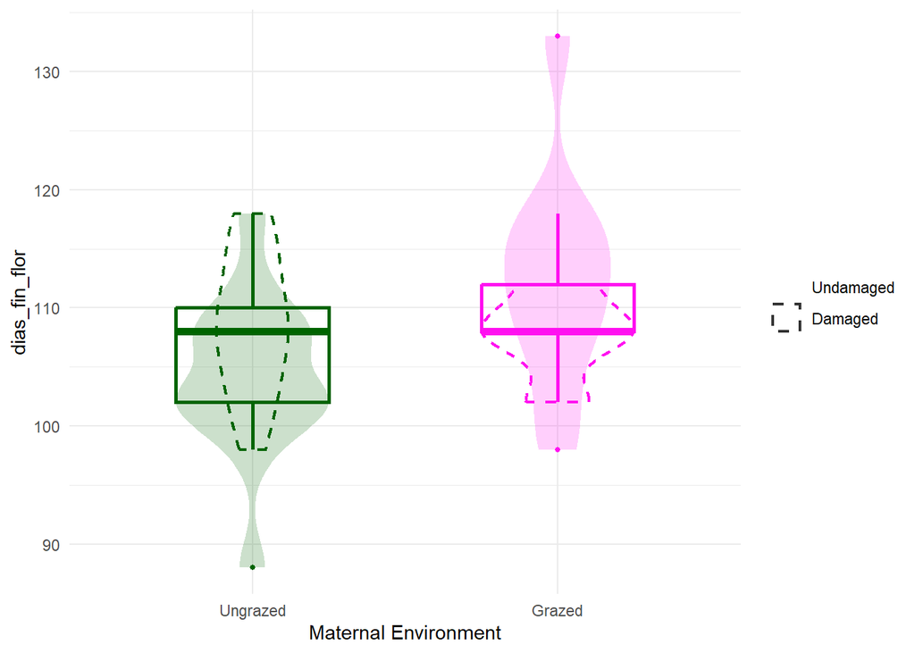

### M.polymorpha - dias_fin DE FRUCTIFICACIÓN

**dias_fin_fruto ~ trat + clip + trat:clip**

n = **51**

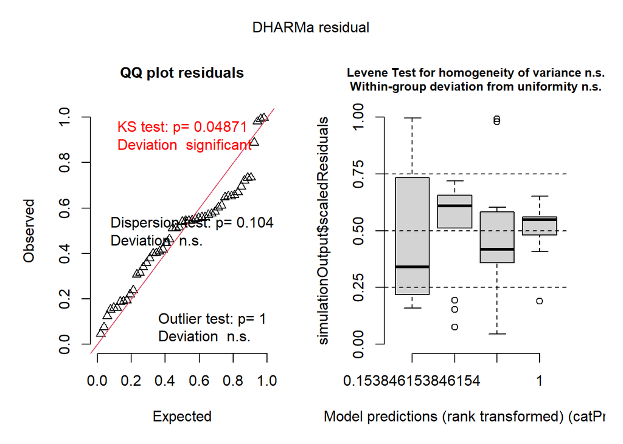

##### MEdias_fin_fruto Post-hoc Comparisons with Tukeys HSD

| contrast | trat | estimate | SE | df | z.ratio | p.value |
| --- | --- | --- | --- | --- | --- | --- |
| no - yes | ex | -0.0821106 | 0.0364123 | Inf | -2.2550220 | 0.0241319 |
| no - yes | gra | 0.0305008 | 0.0365993 | Inf | 0.8333722 | 0.4046349 |

| contrast | clip | estimate | SE | df | z.ratio | p.value |
| --- | --- | --- | --- | --- | --- | --- |
| ex - gra | no | -0.0855482 | 0.0371008 | Inf | -2.3058295 | 0.0211202 |
| ex - gra | yes | 0.0270633 | 0.0359012 | Inf | 0.7538262 | 0.4509536 |

ANOVA Results for MEdias_fin_fruto Model

| Response | Predictor | Chisq | Df | Pr(>Chisq) |
| --- | --- | --- | --- | --- |
| ME dias_fin_fruto | trat | 1.127 | 1 | 0.288 |
| ME dias_fin_fruto | clip | 1.022 | 1 | 0.312 |
| ME dias_fin_fruto | trat:clip * | 4.758 | 1 | 0.029 |

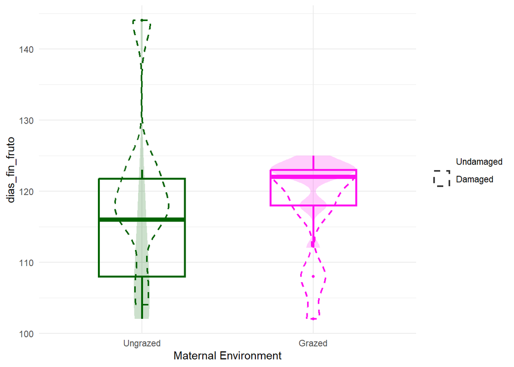

### M.polymorpha - ESPERANZA DE VIDA

**dias_muerte ~ trat + clip + trat:clip**  
n = **56**

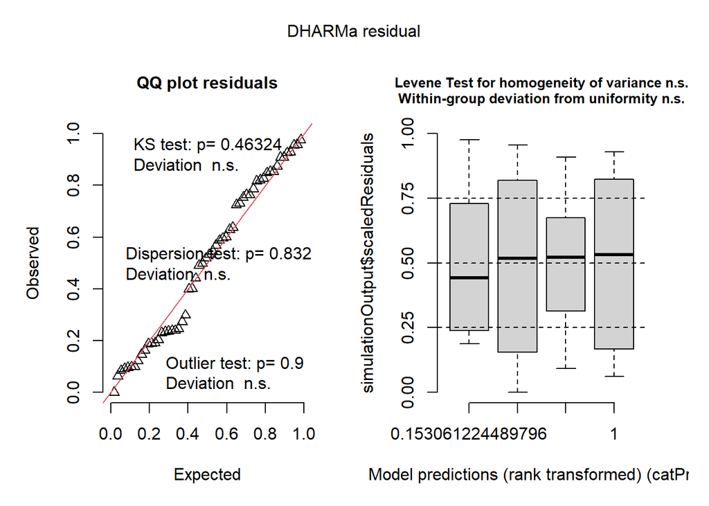

##### MEdias_muerte Post-hoc Comparisons with Tukeys HSD

| contrast | trat | estimate | SE | df | z.ratio | p.value |
| --- | --- | --- | --- | --- | --- | --- |
| no - yes | ex | -0.0383299 | 0.0467194 | Inf | -0.8204268 | 0.4119729 |
| no - yes | gra | 0.0424274 | 0.0505398 | Inf | 0.8394855 | 0.4011969 |

| contrast | clip | estimate | SE | df | z.ratio | p.value |
| --- | --- | --- | --- | --- | --- | --- |
| ex - gra | no | -0.0200580 | 0.0496385 | Inf | -0.4040816 | 0.6861527 |
| ex - gra | yes | 0.0606993 | 0.0476760 | Inf | 1.2731633 | 0.2029601 |

ANOVA Results for MEdias_muerte Model

| Response | Predictor | Chisq | Df | Pr(>Chisq) |
| --- | --- | --- | --- | --- |
| ME dias_muerte | trat | 0.407 | 1 | 0.523 |
| ME dias_muerte | clip | 0.001 | 1 | 0.974 |
| ME dias_muerte | trat:clip | 1.377 | 1 | 0.241 |

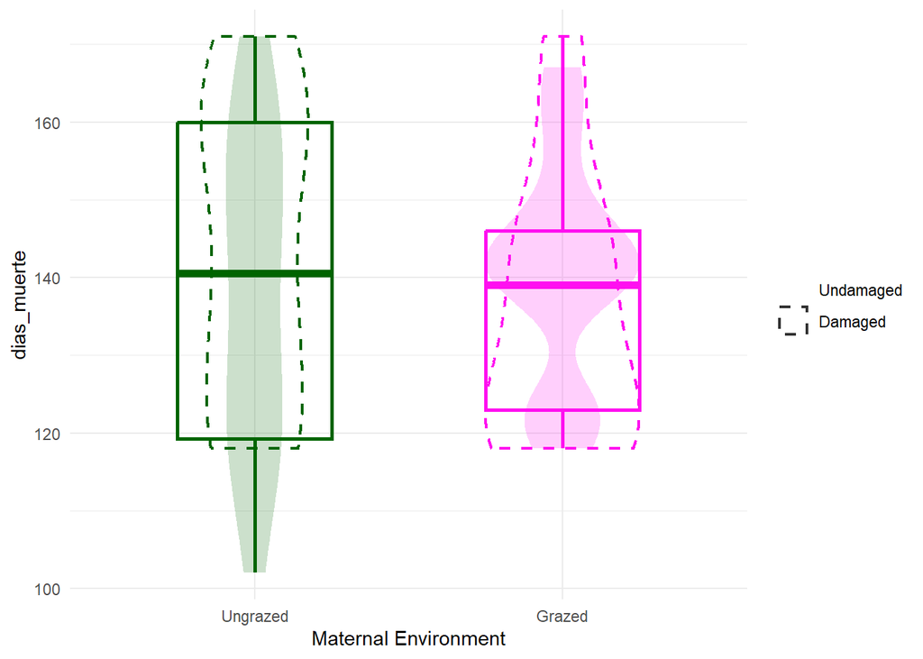

### M.polymorpha - FENOLES

**fenoles ~ trat + clip + trat:clip**  
n = **39**

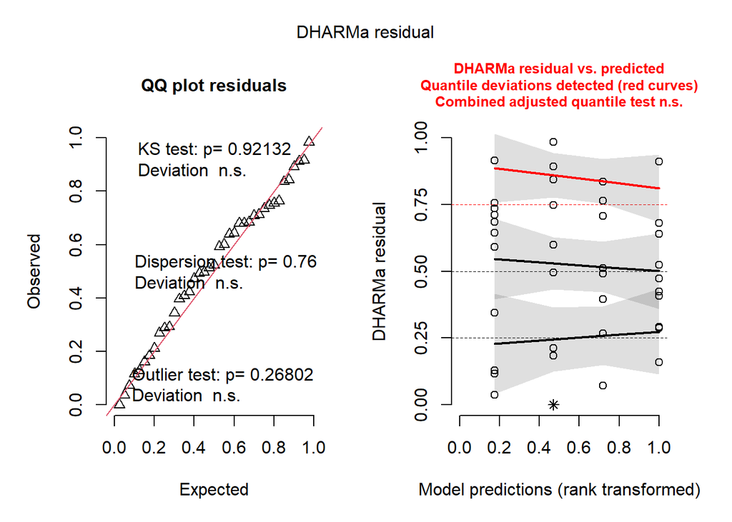

R² = **-0.0068434**

##### MEfenoles Post-hoc Comparisons with Tukeys HSD

| contrast | trat | estimate | SE | df | t.ratio | p.value |
| --- | --- | --- | --- | --- | --- | --- |
| no - yes | ex | -3.007764 | 5.333820 | 35 | -0.5639042 | 0.5764151 |
| no - yes | gra | -7.126091 | 4.680571 | 35 | -1.5224833 | 0.1368728 |

| contrast | clip | estimate | SE | df | t.ratio | p.value |
| --- | --- | --- | --- | --- | --- | --- |
| ex - gra | no | 3.3004747 | 4.933755 | 35 | 0.6689580 | 0.5079110 |
| ex - gra | yes | -0.8178523 | 5.100534 | 35 | -0.1603464 | 0.8735301 |

ANOVA Results for MEfenoles Model

| Response | Predictor | Sum Sq | Df | F value | Pr(>F) |
| --- | --- | --- | --- | --- | --- |
| ME fenoles | trat | 16.436 | 1 | 0.136 | 0.714 |
| ME fenoles | clip | 277.029 | 1 | 2.299 | 0.138 |
| ME fenoles | trat:clip | 40.583 | 1 | 0.337 | 0.565 |
| ME fenoles | Residuals | 4217.241 | 35 | NA | NA |

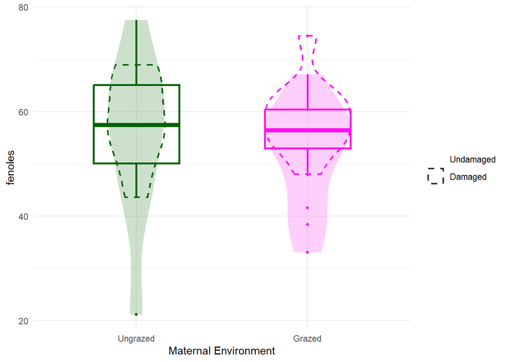

### M.polymorpha - BIOMASA

**biomass ~ trat + clip + trat:clip**  
n = **56**

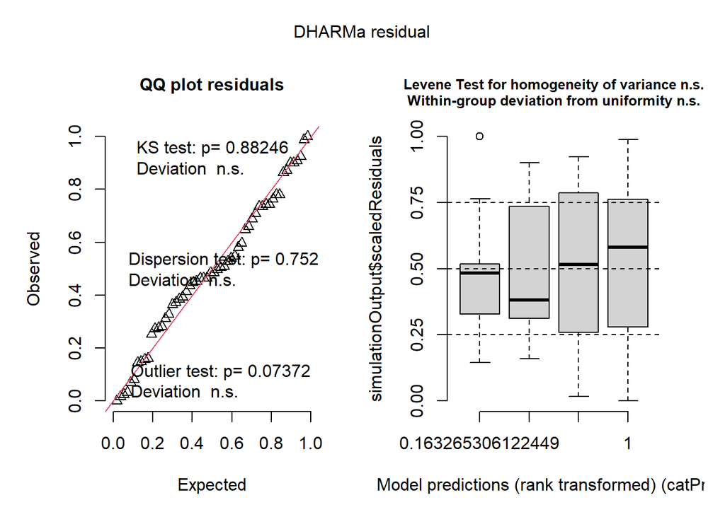

R² = **0.0632385**

##### MEbiomass Post-hoc Comparisons with Tukeys HSD

| contrast | trat | estimate | SE | df | t.ratio | p.value |
| --- | --- | --- | --- | --- | --- | --- |
| no - yes | ex | 1.6372067 | 0.6386922 | 52 | 2.5633734 | 0.0132977 |
| no - yes | gra | 0.0732952 | 0.6881043 | 52 | 0.1065176 | 0.9155816 |

| contrast | clip | estimate | SE | df | t.ratio | p.value |
| --- | --- | --- | --- | --- | --- | --- |
| ex - gra | no | 0.9485633 | 0.6774354 | 52 | 1.4002270 | 0.1673840 |
| ex - gra | yes | -0.6153481 | 0.6499974 | 52 | -0.9466932 | 0.3481738 |

ANOVA Results for MEbiomass Model

| Response | Predictor | Sum Sq | Df | F value | Pr(>F) |
| --- | --- | --- | --- | --- | --- |
| ME biomass | trat | 0.251 | 1 | 0.082 | 0.776 |
| ME biomass | clip · | 11.648 | 1 | 3.807 | 0.056 |
| ME biomass | trat:clip | 8.490 | 1 | 2.775 | 0.102 |
| ME biomass | Residuals | 159.092 | 52 | NA | NA |

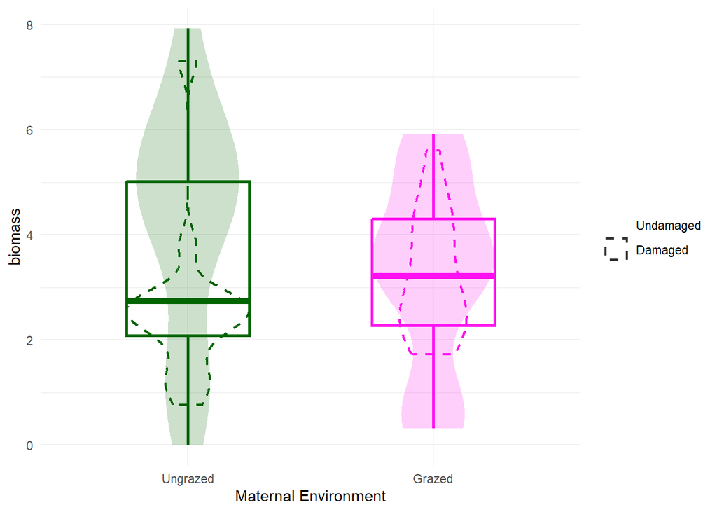

### M.polymorpha - Diámetro de la raíz

**AvgDiam.mm. ~ trat + clip + trat:clip**  
n = **38**

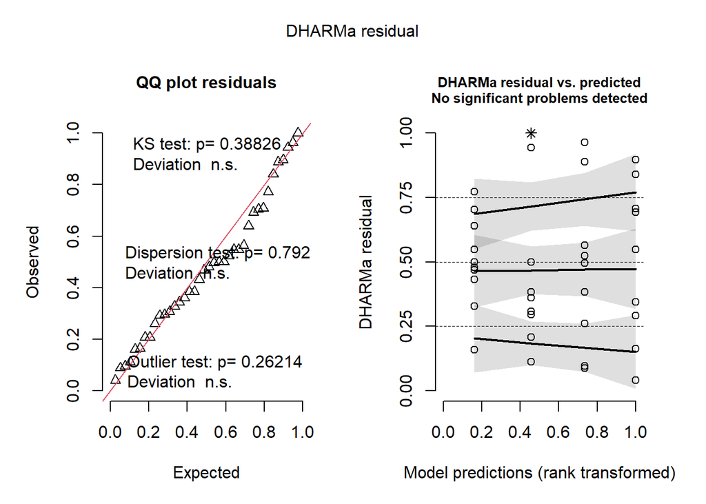

R² = **0.0683633**

##### MEAvgDiam.mm. Post-hoc Comparisons with Tukeys HSD

| contrast | trat | estimate | SE | df | t.ratio | p.value |
| --- | --- | --- | --- | --- | --- | --- |
| no - yes | ex | 0.0123089 | 0.0315604 | 34 | 0.3900109 | 0.6989611 |
| no - yes | gra | -0.0599389 | 0.0315604 | 34 | -1.8991819 | 0.0660523 |

| contrast | clip | estimate | SE | df | t.ratio | p.value |
| --- | --- | --- | --- | --- | --- | --- |
| ex - gra | no | 0.0660389 | 0.0315604 | 34 | 2.0924623 | 0.0439350 |
| ex - gra | yes | -0.0062089 | 0.0315604 | 34 | -0.1967305 | 0.8452097 |

ANOVA Results for MEAvgDiam.mm. Model

| Response | Predictor | Sum Sq | Df | F value | Pr(>F) |
| --- | --- | --- | --- | --- | --- |
| ME AvgDiam.mm. | trat | 0.008 | 1 | 1.797 | 0.189 |
| ME AvgDiam.mm. | clip | 0.005 | 1 | 1.139 | 0.293 |
| ME AvgDiam.mm. | trat:clip | 0.012 | 1 | 2.620 | 0.115 |
| ME AvgDiam.mm. | Residuals | 0.160 | 34 | NA | NA |

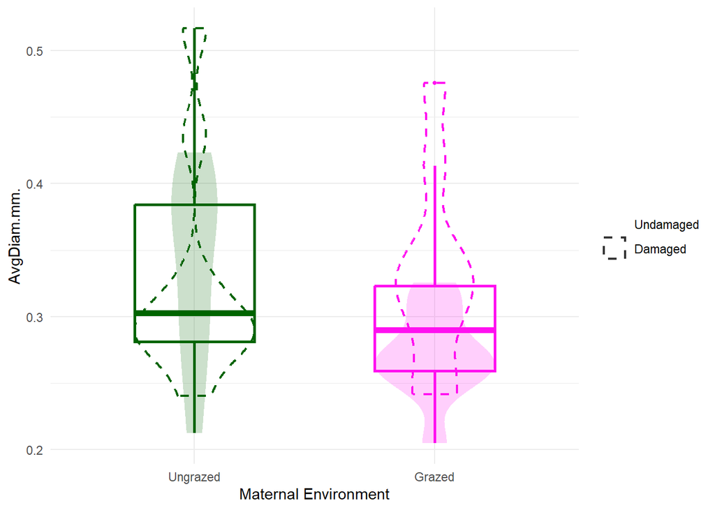

### M.polymorpha - Root Tissue Density (RTD)

**RTD ~ trat + clip + trat:clip**  
n = **38**

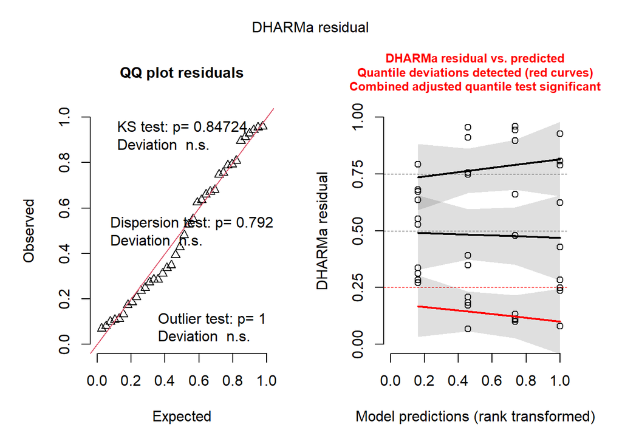

R² = **-0.0200283**

##### MERTD Post-hoc Comparisons with Tukeys HSD

| contrast | trat | estimate | SE | df | t.ratio | p.value |
| --- | --- | --- | --- | --- | --- | --- |
| no - yes | ex | 0.0778069 | 0.0560894 | 34 | 1.3871958 | 0.1744090 |
| no - yes | gra | -0.0288232 | 0.0560894 | 34 | -0.5138801 | 0.6106597 |

| contrast | clip | estimate | SE | df | t.ratio | p.value |
| --- | --- | --- | --- | --- | --- | --- |
| ex - gra | no | 0.0430490 | 0.0560894 | 34 | 0.7675073 | 0.4480775 |
| ex - gra | yes | -0.0635811 | 0.0560894 | 34 | -1.1335685 | 0.2649056 |

ANOVA Results for MERTD Model

| Response | Predictor | Sum Sq | Df | F value | Pr(>F) |
| --- | --- | --- | --- | --- | --- |
| ME RTD | trat | 0.001 | 1 | 0.067 | 0.797 |
| ME RTD | clip | 0.006 | 1 | 0.381 | 0.541 |
| ME RTD | trat:clip | 0.027 | 1 | 1.807 | 0.188 |
| ME RTD | Residuals | 0.507 | 34 | NA | NA |

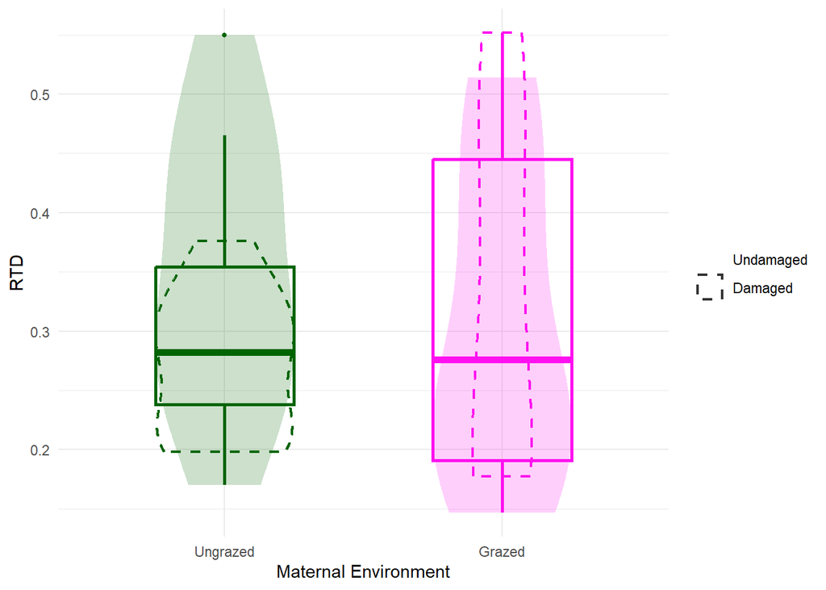

### M.polymorpha - Specific Root Length (SRL)

**SRL ~ trat + clip + trat:clip**  
n = **38**

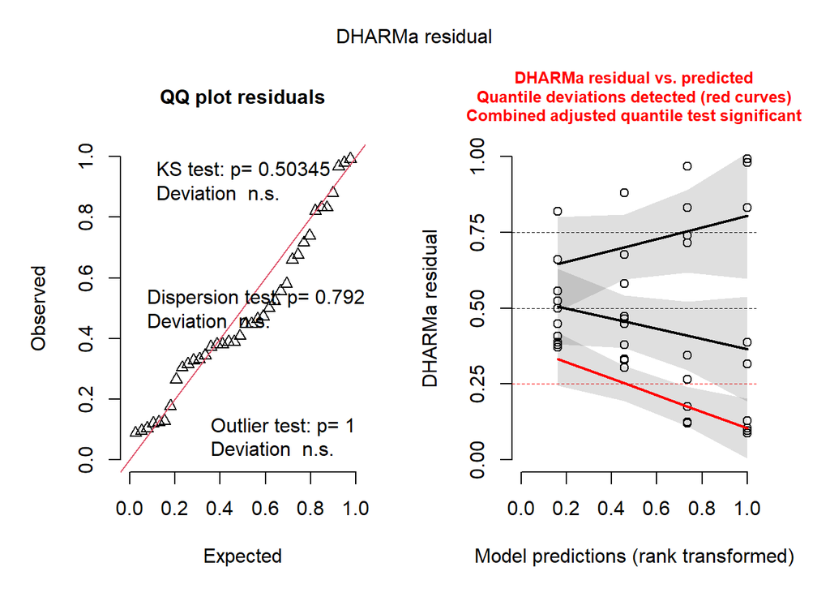

R² = **0.1108261**

##### MESRL Post-hoc Comparisons with Tukeys HSD

| contrast | trat | estimate | SE | df | t.ratio | p.value |
| --- | --- | --- | --- | --- | --- | --- |
| no - yes | ex | 0.0354703 | 0.0181544 | 34 | 1.953811 | 0.0589905 |
| no - yes | gra | -0.0350482 | 0.0181544 | 34 | -1.930561 | 0.0619118 |

| contrast | clip | estimate | SE | df | t.ratio | p.value |
| --- | --- | --- | --- | --- | --- | --- |
| ex - gra | no | 0.0319469 | 0.0181544 | 34 | 1.759730 | 0.0874495 |
| ex - gra | yes | -0.0385716 | 0.0181544 | 34 | -2.124642 | 0.0409676 |

ANOVA Results for MESRL Model

| Response | Predictor | Sum Sq | Df | F value | Pr(>F) |
| --- | --- | --- | --- | --- | --- |
| ME SRL | trat | 0.000 | 1 | 0.067 | 0.798 |
| ME SRL | clip | 0.000 | 1 | 0.000 | 0.987 |
| ME SRL | trat:clip ** | 0.012 | 1 | 7.544 | 0.010 |
| ME SRL | Residuals | 0.053 | 34 | NA | NA |

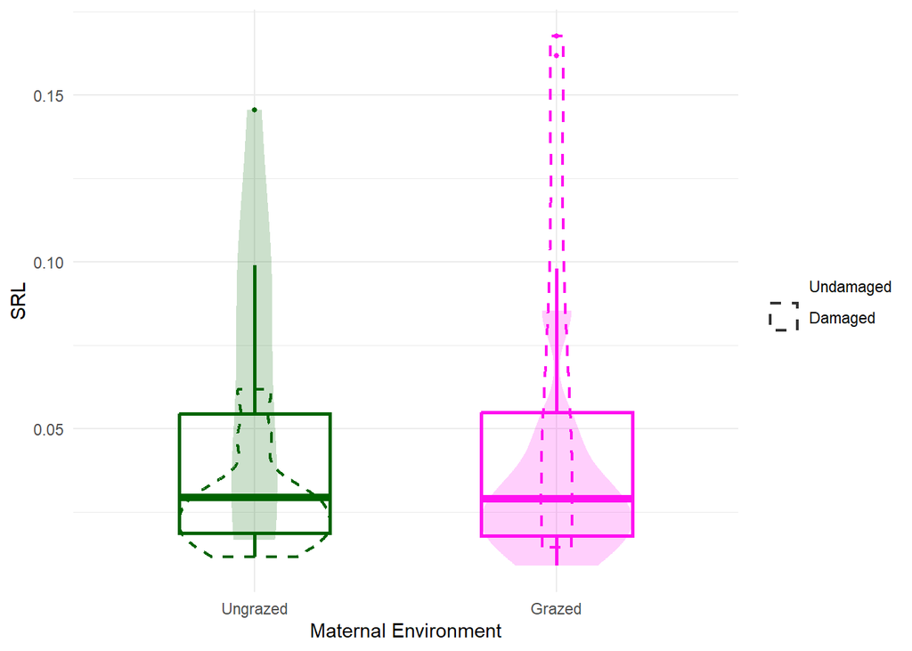